# Art

Aiden Kelly

2023-06-06

# 1, 2, Jango

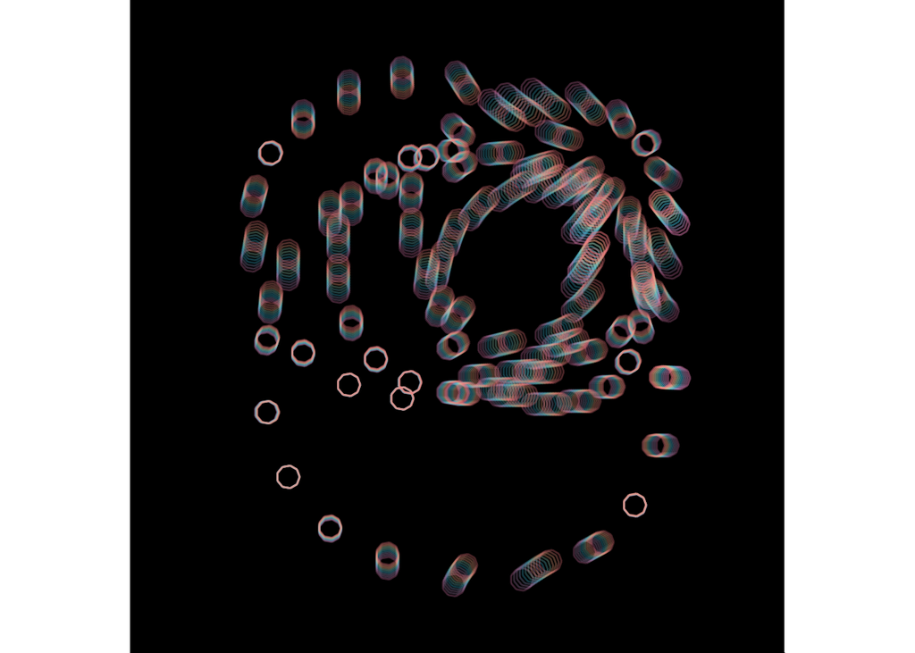

```r
my_palette <- c('#d072a6','#ac84b2','#8795bd','#3db7d3','#6ac5c6','#97d3b8','#ffb18a','#f99586','#f27981')

use_seed(1) |>
  scene_bubbles(n = 5,
                grain = 20) |>
  unfold_warp(iterations = 10) |>
  unfold_loop(points = 10,
              radius = .05) |>
  style_ribbon(palette = palette_manual(my_palette), background = "black")
```

Description: 1,2, Jango shows us how there can be so much disarray in the world, yet we still try to make sense of it. When I first made it I tried to identify a pattern in how it was made. I was able to identify that there were about 3 loops made of points of nonagons, but was unable to identify a pattern to explain the deviations from their predicted positions. It reminded me of looking at a rock face or something else in nature. Where I feel like there are parts that I understand and can explain, but there is so much more stuff going on that it just seems random.

Explanation: use_seed() will set the seed for the RNG. Setting the value to a speific value will make it so we get the same results every time. Next, the scene_bubbles lays out 5 circles made of 20 points each. Unfold_warp will then add some noise to the circles we have. The iteration was set to 10, so it repeat the noise adding process 10 times. The unfold loop will then take every point and and turn in into a polygon with n-1 sides, where n is the points argument. We also specify the radius of the points. Finally, the style_ribbon function converts the object to a ggplot2 image using the “ribbon” style. It also sets the color palette of the image to my defined palette, my_palette, and the background color black.

# GGplanet

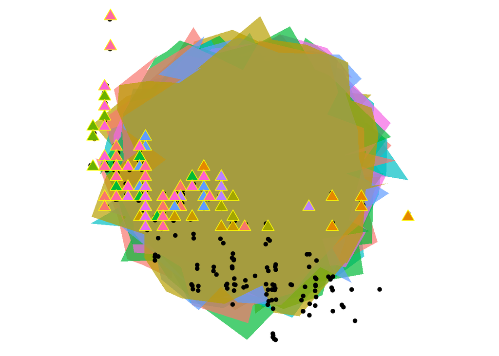

```r
#plot #1
p2 <- mpg |>
  ggplot(aes(x=displ,y=hwy, fill = manufacturer))+
  geom_jitter(show.legend = FALSE, size = 1.5) +
   geom_point(data=mpg %>%
                filter(hwy > 22),
              pch = 24,
              size=4,
              colour = "yellow",show.legend = FALSE) +
   theme_void()

# plot number 2
# Define a function to generate random polygons
generate_random_polygon <- function(id, n_points) {
  data.frame(
    id = id,
    x = cos(seq(0, 2*pi, length.out = n_points)) + rnorm(n_points, sd = 0.1),
    y = sin(seq(0, 2*pi, length.out = n_points)) + rnorm(n_points, sd = 0.1)
  )
}
# Generate a dataset of 10 random polygons
polygons <- bind_rows(lapply(1:10, generate_random_polygon, n_points = 30))
# Generate a color for each polygon
polygons <- polygons %>%
  group_by(id) %>%
  mutate(color = sample(rainbow(10), 1))
# Plot the polygons
p<-ggplot(polygons, aes(x = x, y = y, group = id, fill = color)) +
  geom_polygon(alpha = 0.7, show.legend = FALSE) +
  theme_void() +
  coord_fixed()


# combine the plots
grob <- ggplotGrob(p2)
combined_plot <- p +
  annotation_custom(grob, xmin = -Inf, xmax = Inf, ymin = -Inf, ymax = Inf)
combined_plot
```

Description: GGplanet is home to none, but if there was anyboy there they would not be having a good time. Its vast, colorful mountain ranges have been bombarded by poison gas. Fleets of star ships have been carpet bombing the small planet. Who knows why?